# Prelim 1 Review

Sep 20 - 27, 2018

## About This Document

- List (not exhaustive) of main topics covered in lectures/labs so far
- Practice problems on some of the topics
- Recommended exercises from textbook
- Will be posted on blackboard under 'Sample Questions'
- will be updated and used in the next lecture as well

> Solutions will only be worked out in lecture, but piazza is a great platform to discuss your work with peers

## Topic: Sampling and Experimental Design

- Population vs. Sample
- Correlation vs. Causation, confounding factors
- Sampling techniques
- Basics of Experimental Design
- Approximate 95% confidence interval for population proportion

## Topic: Data Visualization

- Types of Variables
- Plots for one categorical variable
- Plots for joint information in two categorical variables
- Plots for one quantitative variable (histogram, boxplots)
- Plots for two quantitative variable (scatterplot)

> good practice: Add title, labels of axes, specify units where appropriate

## Topic: Descriptive Statistics

- Mean, median, mode, quantiles, percentiles
- Standard deviation, variance, IQR
- z-scores, empirical rules

## Topic: Basics of Probability

- Trial, outcome, sample space, events
- Disjoint events
- Union, intersection

## Topic: Conditional Probability

- Conditional probability
- Independence
- Law of Total Probability
- Bayes Theorem
- Sensitivity, Specificity and Prevalence

## Topic: Random Variable (RV)

- Random Variables as function
- Discrete Random Variable
- Probability mass function (pmf): 'idealized' histogram
- Expectation and Variance
- Expectation and Variance of Sum of Variables

## Topic: Common Discrete RVs

- Bernoulli(\(p\))
- Track 'success' or 'failure'
- Binomial(\(n,p\))
- Count number of success in \(n\) **independent** trials with **same** success probability \(p\)
- Poisson(\(\lambda\))
- Count number of 'events/occurrence'
- occurence of an event does not depend on past events, rate of event occurrence constant
- note: not to confuse this 'event' with 'sets of outcomes'
- **Examples**?

## Topic: Monte Carlo Simulation

- Simulate trials or experiments on computer
- Count number of occurence of an event after repeating many times
- Fraction gives you an idea of ''long run frequency''
- Examples
- Toss a coin 3 times, Roll two dice
- Simple Random Sample to calculate proportion of graduate students
- Simulate rainy and sunny days

## Practice Problems

## Topic: Sampling and Experimental Design

## Sample Questions

## Problem 1

We want to estimate the proportion of Cornell graduate students in Wegmans on a Friday evening. We randomly selected \(100\) customers at Wegmans on a Friday night and asked if they are graduate students. \(46\) of them said 'yes'. The population of interest here is

1. All Cornell graduate students;
2. All Customers at Wegmans on a Friday night;
3. All Cornell graduate students at Wegmans on a Friday night;
4. \(46\) graduate students surveyed at Wegmans on the Friday night.

> Population? Sample? Parameter? Statistic?

## Problem 2

What kind of sampling method was used? What if

1. you only surveyed randomly selected customers in the parking lot?
2. you surveyed first 50 customers in each of the two self-serve '7 items or less' lanes?
3. you chose to survey 50 male and 50 female customers at random?
4. you only surveyed 50 randomly selected customers in each of two randomly selected sections (e.g., the vegetable and dessert sections)?

> SRS, (a) convenience, (b) quota, (c) stratified random sampling, (d) cluster

## Problem 3

Consider the SRS sampling before. Provide an approximate \(95\%\) conservative confidence interval for the proportion of graduate students at Wegman's on a Friday night.

> (\(0.46 - 1/\sqrt{100}\), \(0.46 + 1/\sqrt{100}\))

How do you interpret this interval?

> If we select simple random samples of size \(100\) many times and calculate the confidence intervals using this formula, approximately \(95\%\) of these confidence intervals will contain the true proportion of graduate students at Wegman's on a Friday night.

What is your margin of error? How many samples will you need to halve this?

> 400

## Problem 4

List the four fundamental principles of designing an experiment

> Controlling, Randomization, Replication and Blocking

What purpose is served by replication?

> reduces uncertainty of estimates

## Topic: Data Visualization

## Sample Questions

## Problem 1

You want to visualize HW2 scores for BTRY 6010 and compare across different departments. What kind of plots will you use?

> side-by-side boxplot

You want to compare HW1 and HW2 scores of students from different departments

> scatterplot of HW1 vs. HW2, using points of different color for students from different departments

## Concept 2

Describe a histogram

## Concept 3

Interpret a boxplot – percentiles, position of whiskers, outliers

Can we talk about skewness of data distribution from boxplot?

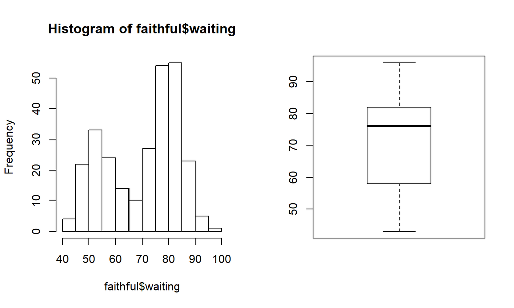

## Topic: Descriptive Statistics

## Sample Questions

## Concept 1: measures of central tendency

Which is more robust to outliers - mean or median?

> median

For a right skewed distribution, which is larger – mean or median?

> mean

## Concept 2: measures of spread

Interpret the following statement: The standard deviation of HW2 scores of BTRY 6010 students is 3.5.

> On average, the HW2 scores of BTRY 6010 students are approximately 3.5 points away from the mean HW2 scores.

Which is more robust to outliers – standard deviation or IQR?

> IQR

## Concept 3: z-scores

Prelim 1 scores are out, and the mean score is 82, with a standard deviation of 4. Alice scored 86.

1. What is Alice's z-score?
2. What is Alice's percentile score?
3. Suppose the distribution of scores is roughly bell-shaped. What is Alice's percentile score?

## Topic: Basics of Probability

## Sample Questions

## Problem 1

True or False?

> Probability that a randomly selected student (say, Alice) scores more than \(50\%\) in Prelim1 is \(0.85\). Probability that another randomly selected student (say, Bob) scores less than or equal to \(50\%\) in Prelim1 is \(0.15\).

Trial? Sample Space? Event of interest \(A\)?

## Problem 2

True or False?

> Probability that a randomly chosen BTRY 6010 student is a Masters student is 0.4. It is possible that the probability of a randomly chosen BTRY 6010 student to be a Masters in Food Science is 0.45.

Trial? Sample Space? Are all the outcomes equally likely? Identify two events of interest: \(A\), \(B\). What can we say about comparing \(P(A)\) and \(P(B)\)?

## Problem 3

True or False?

> Probability that a randomly chosen BTRY 6010 student is a Masters student is 0.4. Probability that a randomly chosen BTRY 6010 student studies Food Science is 0.8. Probability that a randomly chosen BTRY 6010 student is a Masters in Food Science is 0.1.

Identify two events of interest \(A\) and \(B\). What can you say about \(P(A \cup B)\)?

## Problem 4

> Select a student at random from BTRY 6010 class. \(P(2~drinks~last~night) = 0.5\), \(P(late~to~class) = 0.4\). \(P(2~drinks~last~night~or~late~to~class) = 0.7\).

> Are the events '2 drinks last night' and 'late to class' disjoint?

> Are the events '2 drinks last night' and 'late to class' independent?

\(A\): 2 drinks last night, \(B\): late to class

\(P(A) = 0.5\), \(P(B) = 0.4\), \(P(A \cup B) = 0.7\).

\(P(A \cap B) = P(A) + P(B) - P(A \cup B) = 0.5+0.4-0.7 = 0.2\).

\(P(A \cap B) \neq 0\) (not disjoint) and \(P(A \cap B) = P(A) P(B)\) (independent)

## Problem 5

True or False?

> Suppose \(P(A|B) = P(A)\). Then \(P(B|A) = P(B)\).

\(P(A|B) = P(A)\) implies \(\frac{P(A \cap B)}{P(B)} = P(A)\)

So, \(P(A \cap B) = P(A) P(B)\), which in turn implies

\(\frac{P(A \cap B)}{P(A)} = P(B)\). [TRUE]

## Topic: Random Variable

## Sample Questions

## Problem 1

**Textbook Problem 2.35: Hearts Win**

> In a new card game, you start with a well-shuffled full deck and draw 3 cards without replacement. If you draw \(3\) hearts, you win $50. If you draw 3 black cards, you win $25. For any other draws, you win nothing.
1. Create a probability model for the amount you win at this game, and find the expected winnings. Also compute the standard deviation of this distribution.
1. If the game costs $5 to play, what would be the expected value and the standard deviation of the net profit (or loss)? [Hint: profit = winnings-cost; \(X-5\)].
1. If the game costs $5 to play, should you play this game? Explain.

## Topic: Common Discrete Distributions

## Sample Questions

## Topic: Monte Carlo Simulation

## Sample Questions: Monte Carlo and R Commands

## Problem 1

```r
deck = rep(1:13, each=4)
num_simulations <- 1e5
store_handtotal <- rep(0, num_simulations)

for (i in 1:num_simulations){
  hand = sample(deck, 6, replace=TRUE)
  store_handtotal[i] <- sum(hand)
}
mean(store_handtotal)
```

```
## [1] 42.00703
```

Is this correct?

## Problem 2

The following histogram plots the frequency of waiting times of the old faithful. Which argument will you change to plot density instead of raw counts on the y-axis (so that the histogram has a total area of one)?

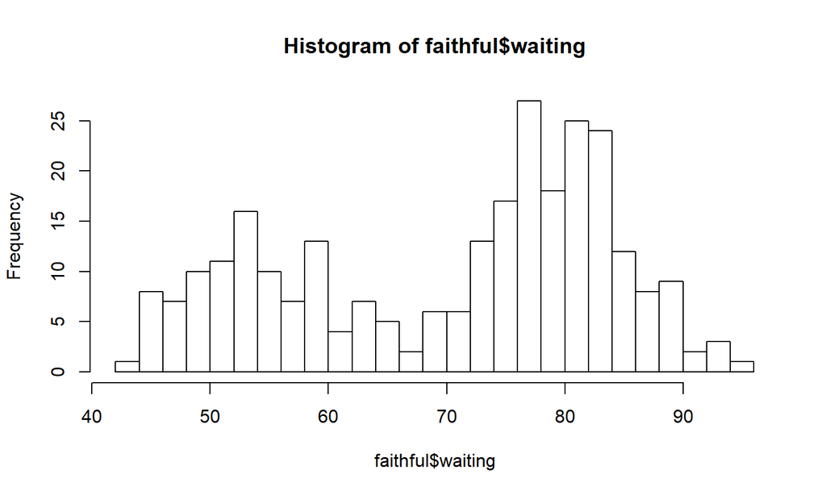

```r
hist(faithful$waiting, freq=TRUE, breaks=30, density = FALSE)
```

## Problem 3: Fill in (A) - (E) with values/variable names

```r
# Calculate Sample Mean
x = c(0, 1, 2, 4, -2, 5, -7)
n = length(x)
tot = (A) # <--- (A)=?

for (i in 1:n)
  tot = tot+x[i]

xbar = tot/(B) # <--- (B)=?

# continued to right panel
```

```r
# Calculate sample std deviation

# continued from left panel
totb = 0

for (i in 1:(C)){ # <--- (C)=?
  totb=totb+(x[i]-(D))^2 # <--- (D)=?
}

s2 = totb/(E) # <--- (E)=?
s = sqrt(s2)
```